# Code and documentation for TC Outlook Verification Procedure

# Data

The files *getDATA_base.R* and *Data_v2.R* are used to read the data from the web pages and create the R data files that we are going to use in this analysis. In order to update them, you will have to go through the code of *getDATA_base.R* and make sure it is reading the data from the correct web pages (there are some changes in the sources from year to year). Also, make sure that the format in said page hasn’t changed, as it usually happens. This change of format might cause errors in the reading process. For now, we stored all the data up to 2015 in the file *alldataX.Rdata*.

```r
rm(list=ls())
load(file="alldataX.Rdata")
```

## Description

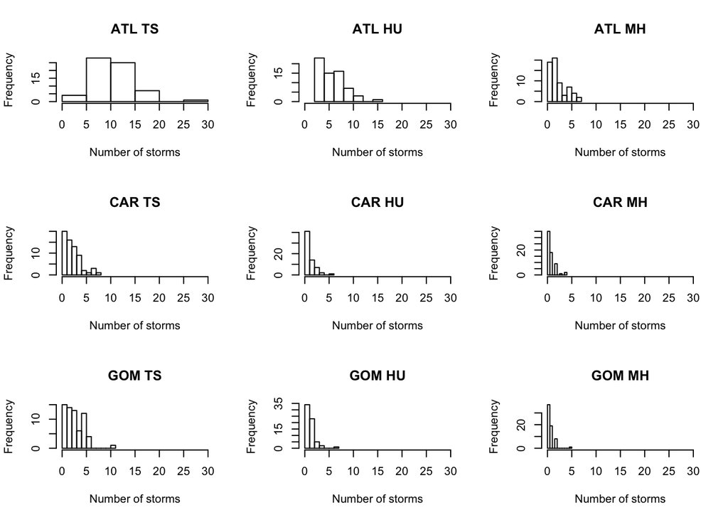

```r
respu<-c("ATL TS","ATL HU","ATL MH",
         "CAR TS","CAR HU","CAR MH",
         "GOM TS","GOM HU","GOM MH")

par(mfrow=c(3,3))
lapply(1:9,function(x)hist(yy0[[x]], main=respu[x], xlab="Number of storms",xlim=c(0,30)))
```

We saved the data indices in the following way:

```r
length(dataX) ## 9 different models: $F_{IB}$ with I=1:3 and B = base, LHF and nino
```

```
[1] 9
```

```r
sapply(1:9,function(x)dim(dataX[[x]])) ## 65 years and then p number of covariates
```

```
     [,1] [,2] [,3] [,4] [,5] [,6] [,7] [,8] [,9]
[1,]   65   65   65   65   65   65   65   65   65
[2,]   56   66   61  112  132  117   68   78   73
```

## Correlations

Climate indices are saved in each of the 9 lists depending on how to define each model. We plot the correlations for the 9th data set, as an example.

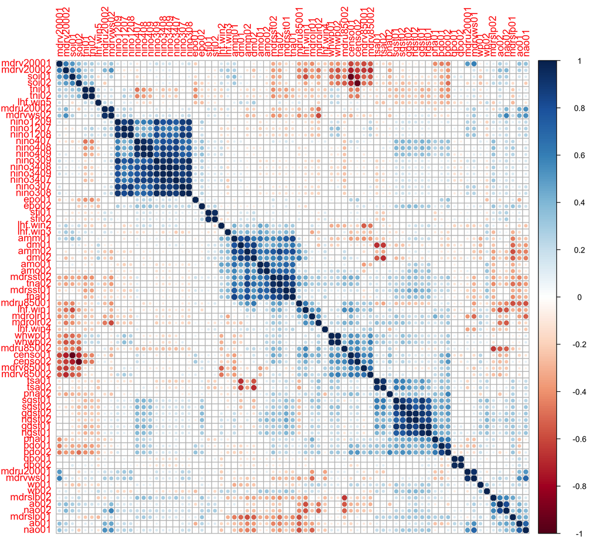

# Models (cluster and cluster + LASSO )

Each set is going to be used to run two models: cluster model and LASSO. LASSO is nested into the cluster model since the variable selection is done using the 10 covariates from the cluster model.

# Verification method

The following cross-validation methods are used:

- SWCV: Sliding window cross-validation.
- RCV: Regular or leave-on-out cross validation is used as a comparison. Again, future data is used to forecast the past.

The following scoring methods are used:

- $H = LS(F_1,y) - LS(F_2,2)$ to compare model $F_1$ and $F_2$
- $D = MSE_{F_1} - MSE_{F_2}$ to compare model $F_1$ and $F_2$

# Processing results

The code to run the verification procedure is in the file *functions_tosubmit.R* and includes the calculation of the SE via nonparametric bootstrap. The file *rep_tosubmit.R* includes all the necessary code to reproduce plots and figures to compare H and MSE for all models, included in the paper.